# ProjectSubmission

Gergana Ilieva

May 25, 2016

## Introduction

For this project, I will be exploring a data set on white wine quality and its properties. My objective is to explore which properties influence the quality of white wine. A start would be an initial exploration of the data. If interesting relationships in the data are discovered, plots will be used to illustrate them.

## Summary Statistics

We need to start with an examination of the structure and schema of the data set.

```
## 'data.frame':    4898 obs. of  13 variables:
##  $ X                   : int  1 2 3 4 5 6 7 8 9 10 ...
##  $ fixed.acidity       : num  7 6.3 8.1 7.2 7.2 8.1 6.2 7 6.3 8.1 ...
##  $ volatile.acidity    : num  0.27 0.3 0.28 0.23 0.23 0.28 0.32 0.27 0.3 0.22 ...
##  $ citric.acid         : num  0.36 0.34 0.4 0.32 0.32 0.4 0.16 0.36 0.34 0.43 ...
##  $ residual.sugar      : num  20.7 1.6 6.9 8.5 8.5 6.9 7 20.7 1.6 1.5 ...
##  $ chlorides           : num  0.045 0.049 0.05 0.058 0.058 0.05 0.045 0.045 0.049 0.044 ...
##  $ free.sulfur.dioxide : num  45 14 30 47 47 30 30 45 14 28 ...
##  $ total.sulfur.dioxide: num  170 132 97 186 186 97 136 170 132 129 ...
##  $ density             : num  1.001 0.994 0.995 0.996 0.996 ...
##  $ pH                  : num  3 3.3 3.26 3.19 3.19 3.26 3.18 3 3.3 3.22 ...
##  $ sulphates           : num  0.45 0.49 0.44 0.4 0.4 0.44 0.47 0.45 0.49 0.45 ...
##  $ alcohol             : num  8.8 9.5 10.1 9.9 9.9 10.1 9.6 8.8 9.5 11 ...
##  $ quality             : int  6 6 6 6 6 6 6 6 6 6 ...
```

```
##        X        fixed.acidity    volatile.acidity  citric.acid
##  Min.   :   1   Min.   : 3.800   Min.   :0.0800   Min.   :0.0000
##  1st Qu.:1225   1st Qu.: 6.300   1st Qu.:0.2100   1st Qu.:0.2700
##  Median :2450   Median : 6.800   Median :0.2600   Median :0.3200
##  Mean   :2450   Mean   : 6.855   Mean   :0.2782   Mean   :0.3342
##  3rd Qu.:3674   3rd Qu.: 7.300   3rd Qu.:0.3200   3rd Qu.:0.3900
##  Max.   :4898   Max.   :14.200   Max.   :1.1000   Max.   :1.6600
##  residual.sugar     chlorides       free.sulfur.dioxide
##  Min.   : 0.600   Min.   :0.00900   Min.   :  2.00
##  1st Qu.: 1.700   1st Qu.:0.03600   1st Qu.: 23.00
##  Median : 5.200   Median :0.04300   Median : 34.00
##  Mean   : 6.391   Mean   :0.04577   Mean   : 35.31
##  3rd Qu.: 9.900   3rd Qu.:0.05000   3rd Qu.: 46.00
##  Max.   :65.800   Max.   :0.34600   Max.   :289.00
##  total.sulfur.dioxide    density             pH          sulphates
##  Min.   :  9.0        Min.   :0.9871   Min.   :2.720   Min.   :0.2200
##  1st Qu.:108.0        1st Qu.:0.9917   1st Qu.:3.090   1st Qu.:0.4100
##  Median :134.0        Median :0.9937   Median :3.180   Median :0.4700
##  Mean   :138.4        Mean   :0.9940   Mean   :3.188   Mean   :0.4898
##  3rd Qu.:167.0        3rd Qu.:0.9961   3rd Qu.:3.280   3rd Qu.:0.5500
##  Max.   :440.0        Max.   :1.0390   Max.   :3.820   Max.   :1.0800
##     alcohol         quality
##  Min.   : 8.00   Min.   :3.000
##  1st Qu.: 9.50   1st Qu.:5.000
##  Median :10.40   Median :6.000
##  Mean   :10.51   Mean   :5.878
##  3rd Qu.:11.40   3rd Qu.:6.000
##  Max.   :14.20   Max.   :9.000
```

Since we’re mostly interested in quality, it would also be interesting to see some basic statistics on that variable separately.

```
##    Min. 1st Qu.  Median    Mean 3rd Qu.    Max.
##   3.000   5.000   6.000   5.878   6.000   9.000
```

We can start with some initial observations:

- There are 4898 observations of 13 numeric variables.
- There seems to be a unique identifier under X.
- Quality is an ordered, categorical, discrete variable. As mentioned in the literature this was on a 0-10 scale, and was rated by at least 3 wine experts. The values ranged only from 3 to 9, with a mean of 5.88 and median of 6.
- From the data dictionary, it appears that fixed acidity /volatile acidity & free sulfur dioxide/total sulfur dioxide might be dependent.

## Basic Statistics on Quality

```
##    Min. 1st Qu.  Median    Mean 3rd Qu.    Max.
##   3.000   5.000   6.000   5.878   6.000   9.000
```

```
##
##    3    4    5    6    7    8    9
##   20  163 1457 2198  880  175    5
```

```
##  Ord.factor w/ 7 levels "3"<"4"<"5"<"6"<..: 4 4 4 4 4 4 4 4 4 4 ...
```

First we will explore this data visually, starting point would be quick histograms of all 12 variables (exception is the unique identifier). The idea behind is to see a quick distribution of the values.

## Quick & Dirty Histograms

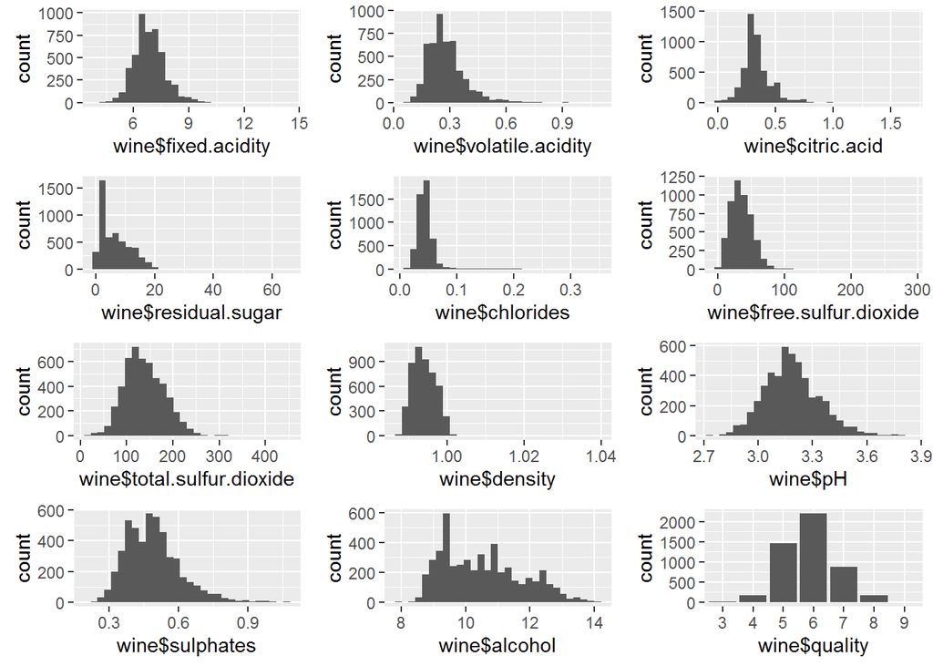

Let us focus a bit more on the wine quality. Although it has a discrete range of only 3-9, we can quickly see that the distribution is quite normal. A large majority of the wines examined received ratings of 5 or 6, and very few received the other ratings. We cannot do much more with this visualization given the distorted data.

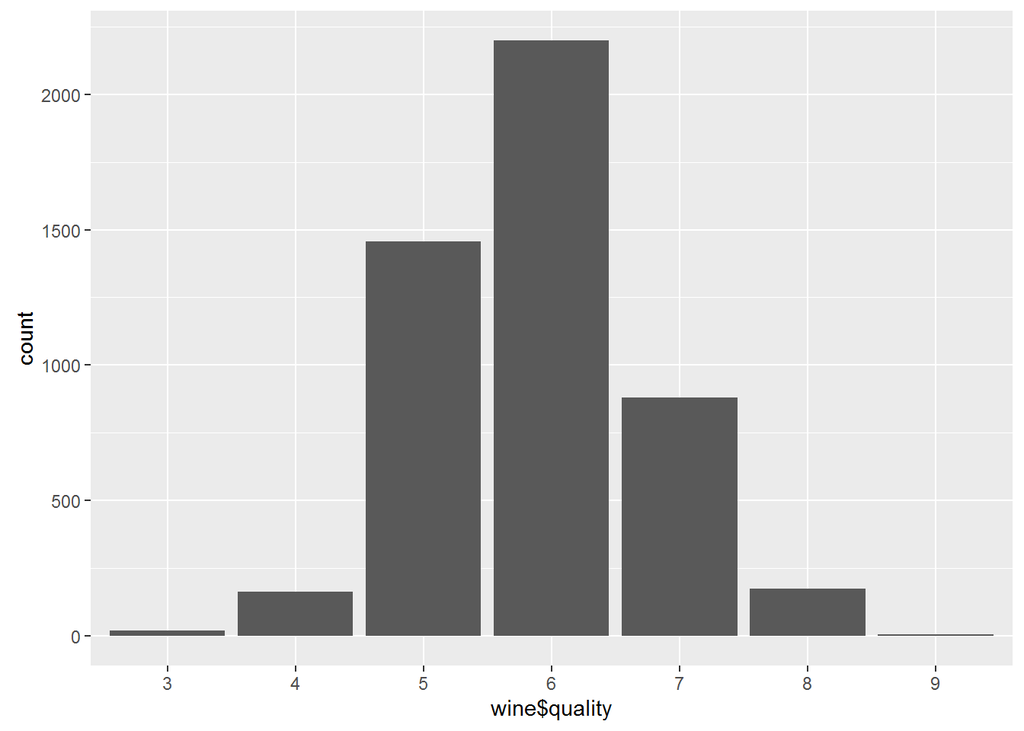

Keeping in mind the quality ratings we can compute another variable distributing wines under good, bad or average.

```
##     bad average    good
##     183    3655    1060
```

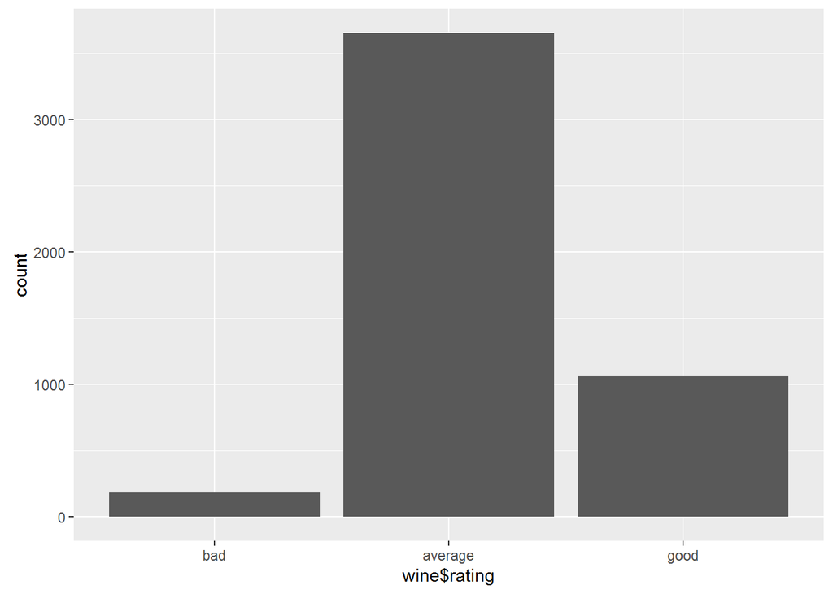

## Distribution and Outliers

From the above histograms (those on the 12 variables), we can easily see that density & pH are close to normally distributed with just a couple of outliers.

Fixed & volatile acidity, sulfur dioxides, sulphates and alcohol all seems to be long-tailed. Both residual sugar & chlorides do have extreme outliers.

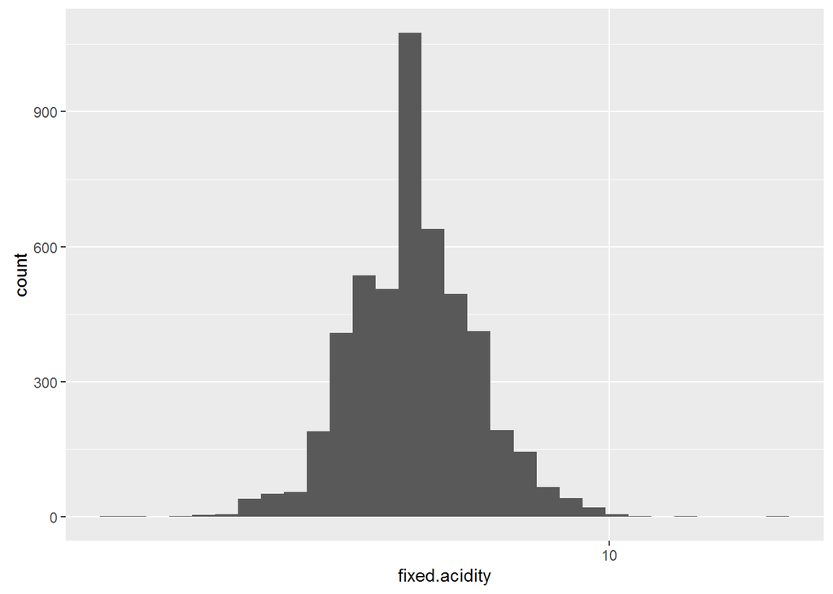

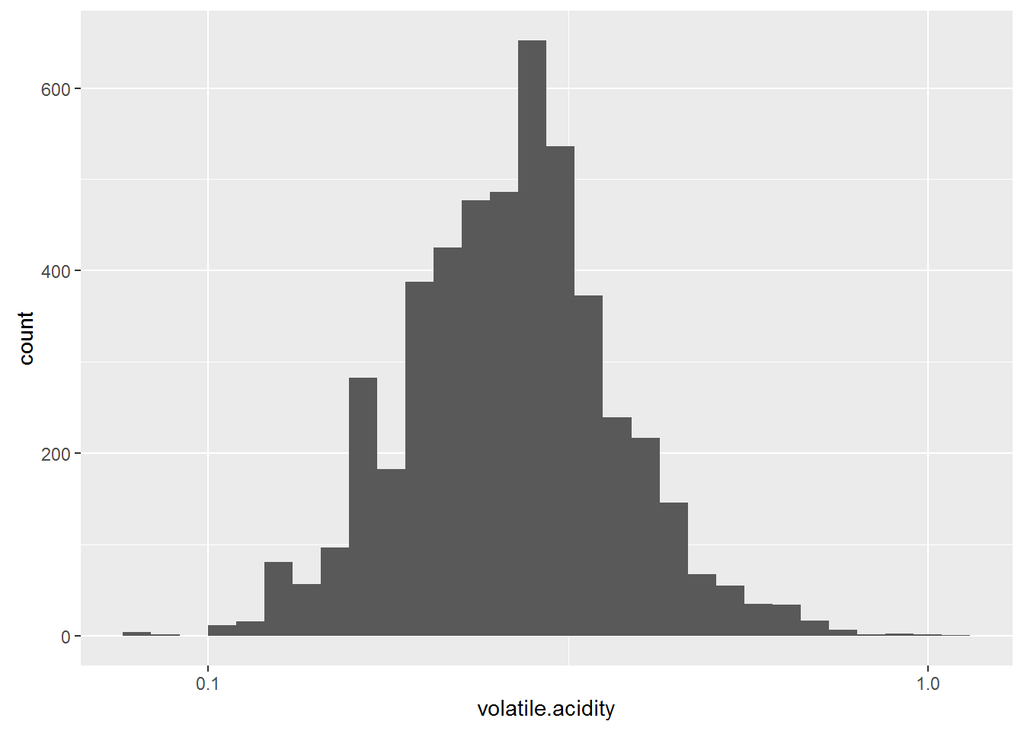

Citric acid has quite a large number of zero values. It is rather interesting whether those are truely zeroes or just non-reported.

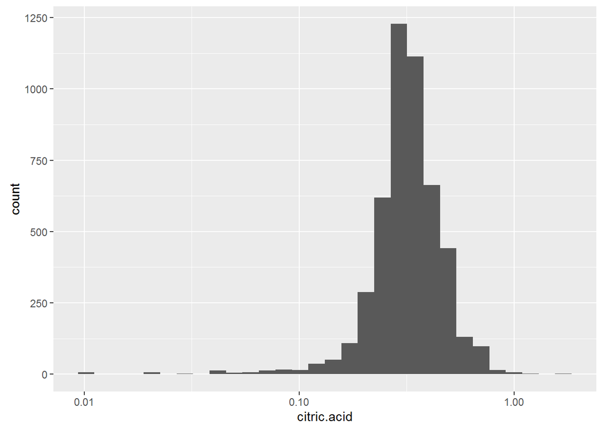

When plotted on a base 10 log scale, fixed & volatile acidity seems to be close to normally-distributed. That is quite expected given that pH is close to normally distributed. If we elaborate more, we find that pH is a measure of acidity on a logarithmic scale. Interestingly, however citric acid is not even close to a normal distribution on a logarithmic scale. It is worth to explore this further:

```
## [1] 19
```

It seems that 19 observations have a value of 0, which is rather concerning whether those observations are just not reported or true zeros.

After reviewing the distributions it seems that there are no other distributions that are worth a sub-classification into a categorical variable. An interesting idea might be to split the residual sugar into ‘dry wine’ vs ‘sweet wine’. But using a [Wikipedia page](https://en.wikipedia.org/wiki/Sweetness_of_wine) it seems that sweet wine can be considered if we have a residual sugar greater than 45 g/L.

It seems that it would be a good idea to combine the fixed, volatile & citric acids in a new variable, given that they are all types of acids, as confirmed by the data documentation. The sum of the acids will be visible in a combined variable called FCV.acidity

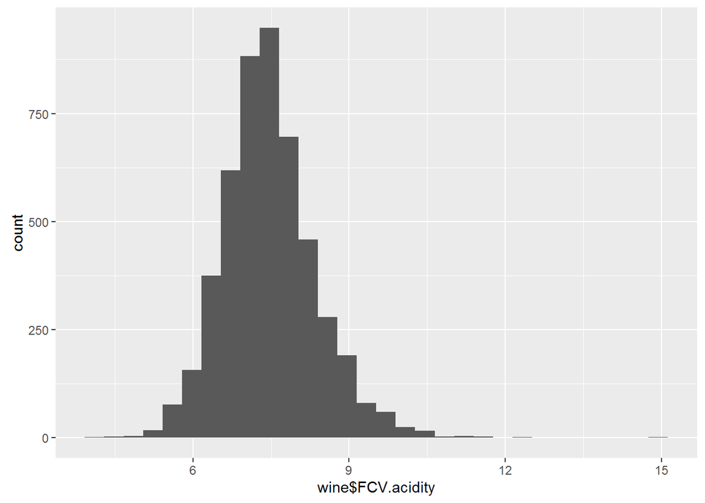

It might be interesting to review the outliers as well, for this purpose we can use univariate boxplots. For this we’ll define a simple function & then plot all the variables.

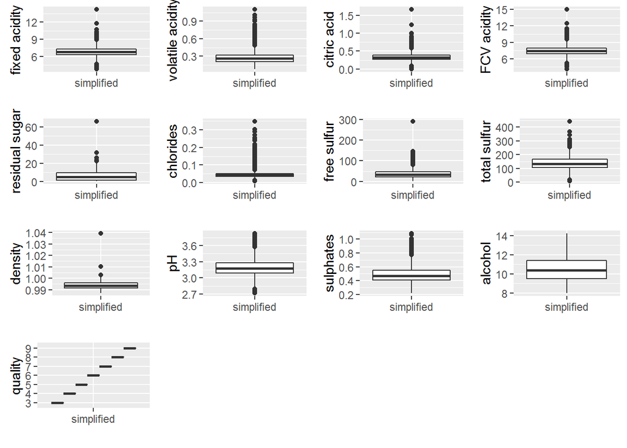

The data in the boxplots is not cleaned in any way other than plotting a select few variables on a logarithmic scale. In order to quickly preview how variables are affecting wine quality/rating I generated a bivariate box plot for each variable crossed with quality or rating respectively.This should help to quickly preview the trends & relationships between the variables, affecting quality of the wines according to the data.

## Bivariate Plot Analysis

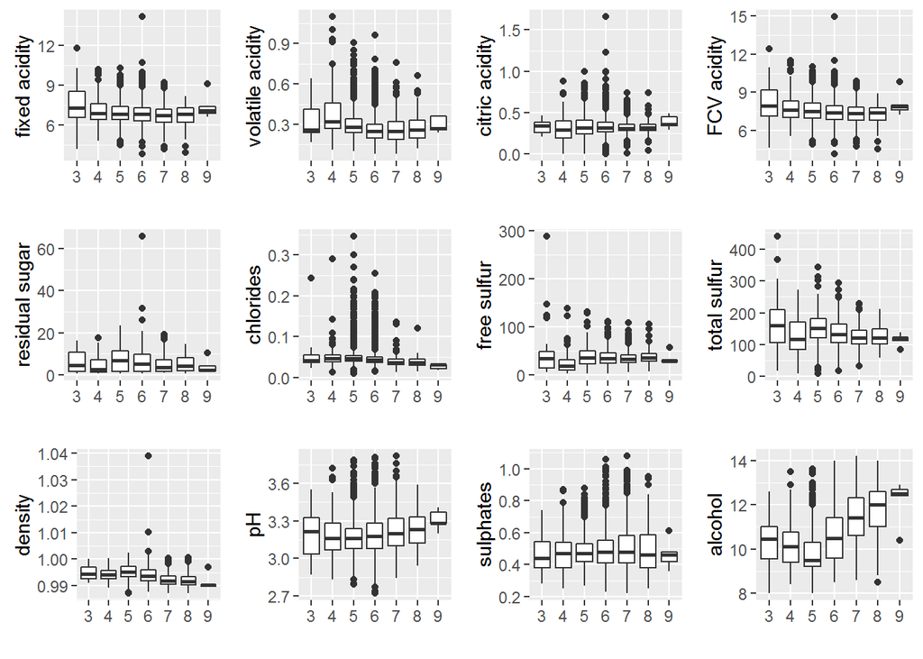

If we look into the quality through the wine rating the picture is a bit clearer. Again pH & alcohol outline above the other variables with the highest average for ‘good’ wines. Thus again confirming that the higher value for those two variables, expecting that the wine would be qualified better on the quality ranking. Given the fact that all acids are similar in their nature, it seems that average acidity for volatile and fixed acidity for ‘average’ and ‘good’ wines respectively are close to each other, however if we look at the boxplots they show quite a disperse which must be kept in mind during the analysis. It is quite peculiar & migth yeild a field for further exploration that the most distinct outliers are present in categories that are not showing strong relationship with quality, such as residual.sugar, free.sulfur.dioxide and density.This is a field for potential further exploration whether those data points are truely outliers and what caused them or just a case of wrong reporting.

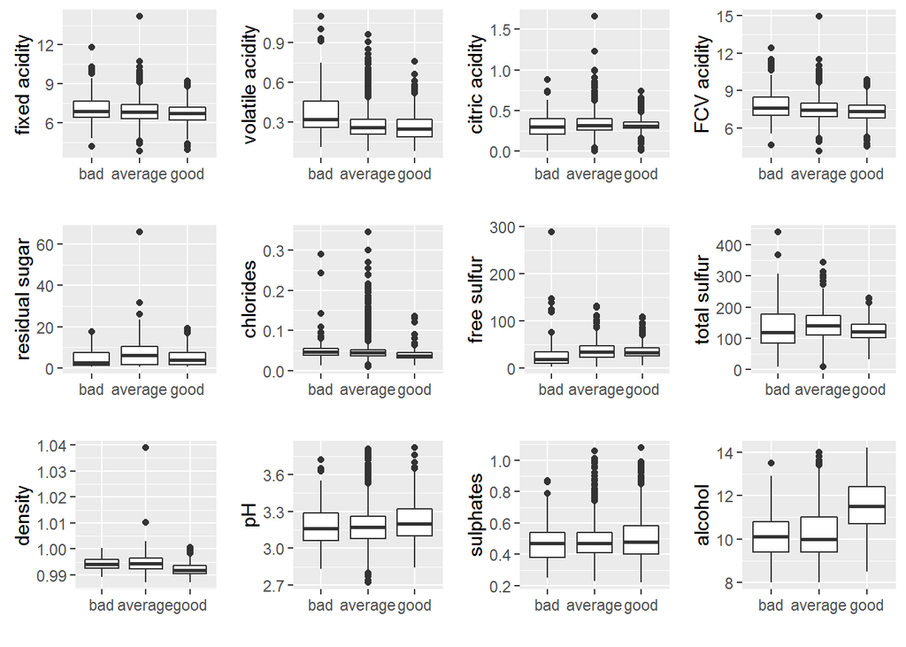

With the help of Pearson’s r I will examine the degree of dependency between quality & the other examined variables.

```
##        fixed.acidity     volatile.acidity          citric.acid
##         -0.113662831         -0.194722969         -0.009209091
##          FCV.acidity log10.residual.sugar      log10.chlordies
##         -0.131377207         -0.064631762         -0.272856661
##  free.sulfur.dioxide total.sulfur.dioxide              density
##          0.008158067         -0.174737218         -0.307123313
##                   pH      log10.sulphates              alcohol
##          0.099427246          0.037766168          0.435574715
```

Based on the results we can say that

It is nice to see how these variables compare if they are plotted against each other & faceted by the wine rating

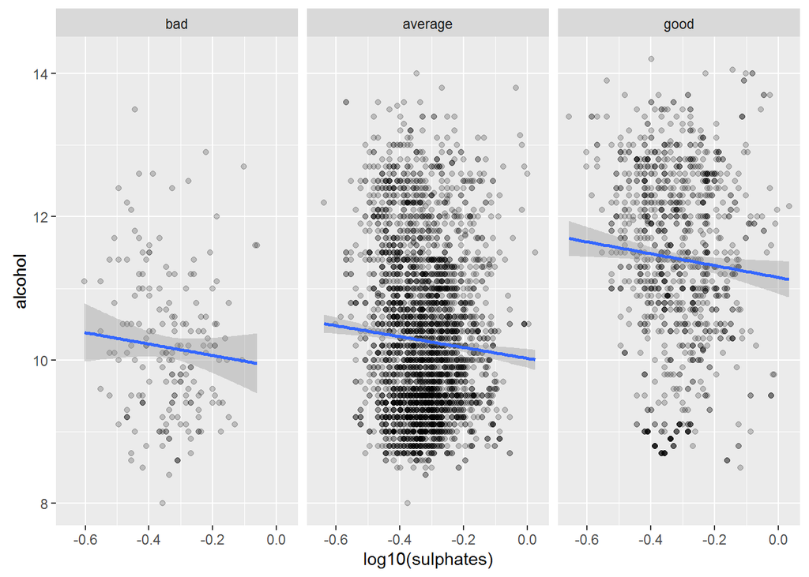

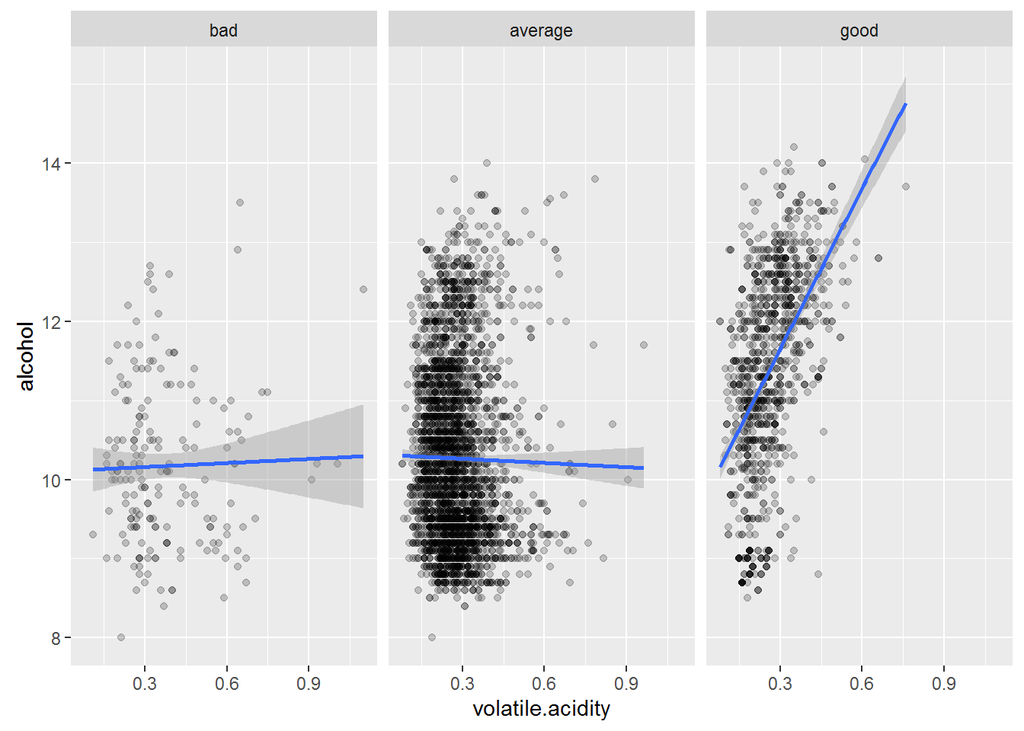

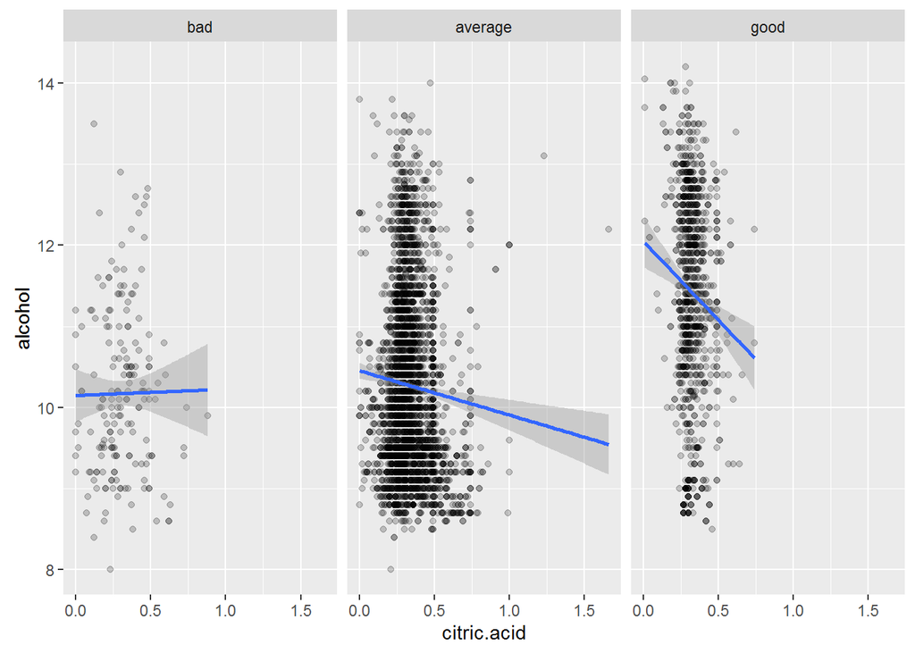

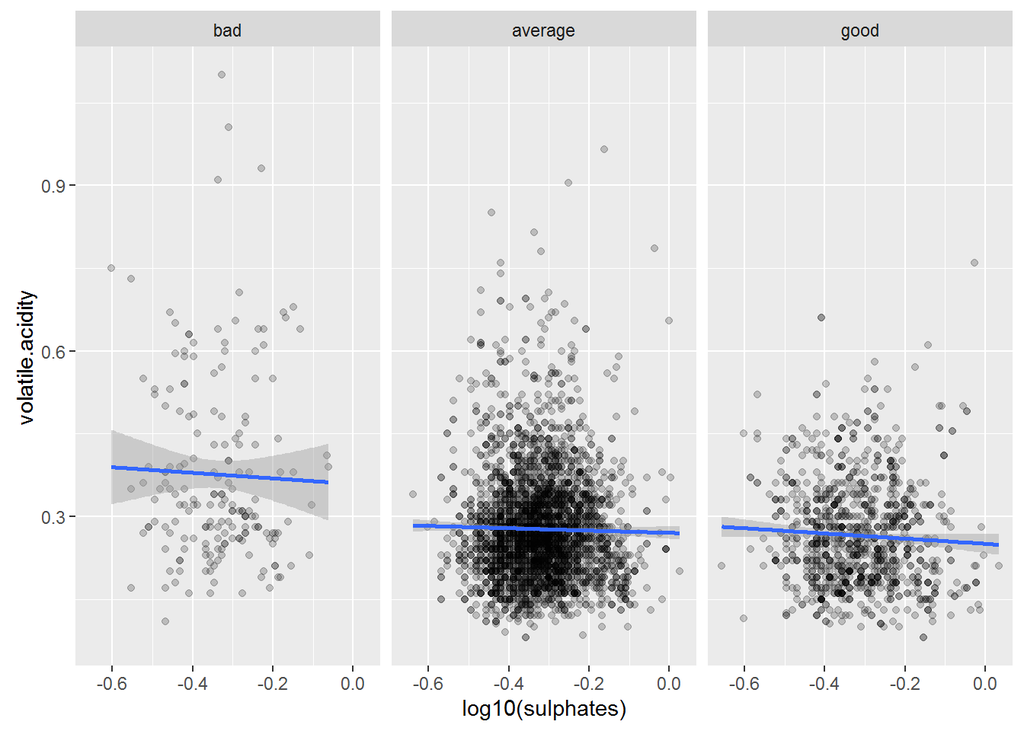

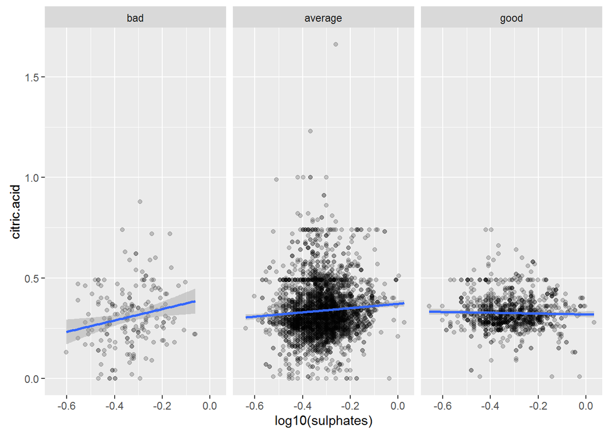

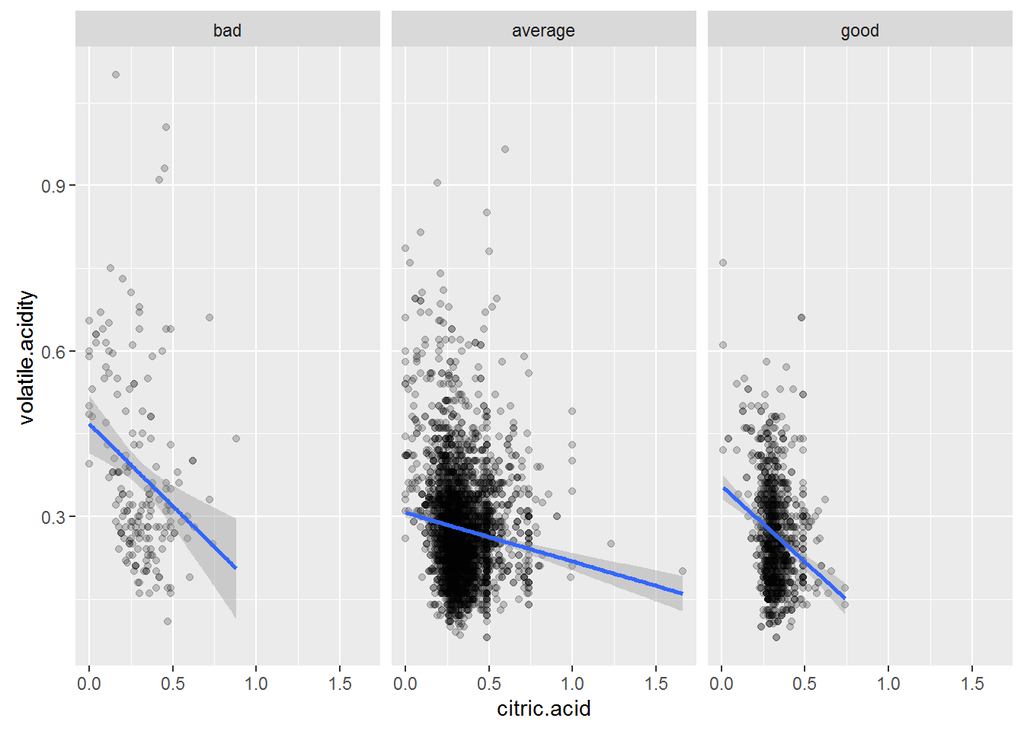

The value of the scatter plots can be questioned, but without a doubt they illustrate that the alcohol content is influencing heavily ratings. The weakest relationship appears to be between alcohol & citric acid, the strongest negative correlation is between the citric acid & volatile acidity.

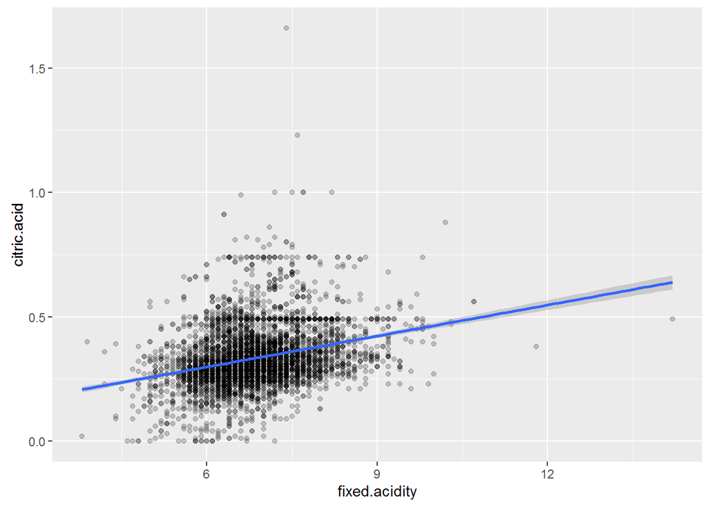

```
##
##  Pearson's product-moment correlation
##
## data:  wine$fixed.acidity and wine$citric.acid
## t = 21.137, df = 4896, p-value < 2.2e-16
## alternative hypothesis: true correlation is not equal to 0
## 95 percent confidence interval:
##  0.2633067 0.3146389
## sample estimates:
##       cor
## 0.2891807
```

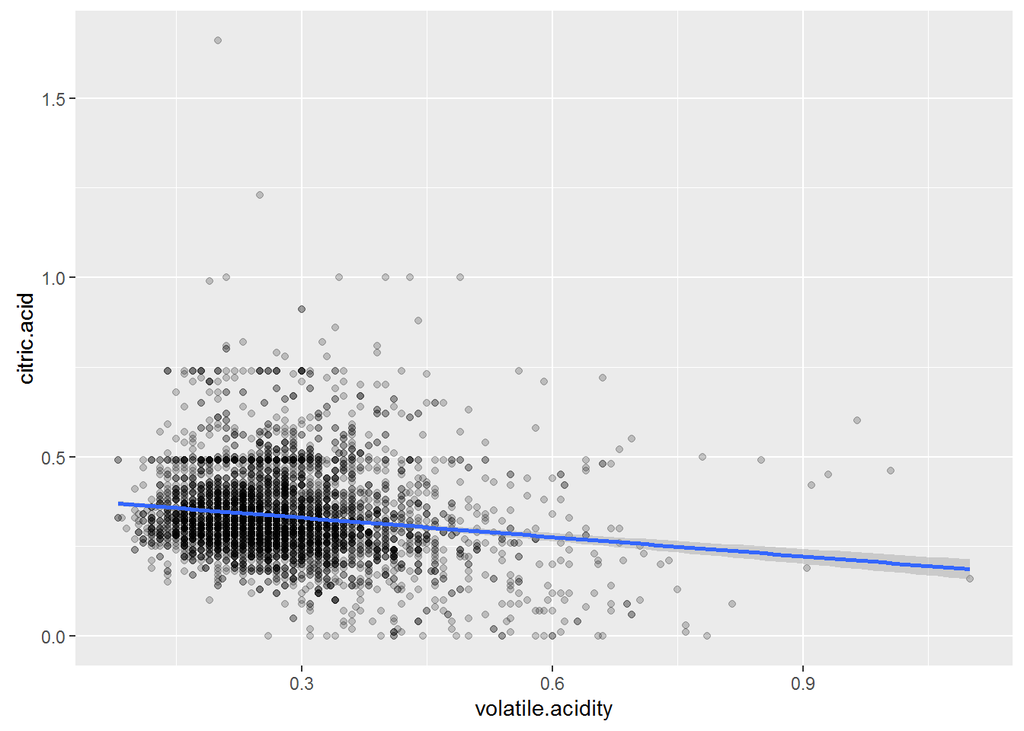

```
##
##  Pearson's product-moment correlation
##
## data:  wine$volatile.acidity and wine$citric.acid
## t = -10.578, df = 4896, p-value < 2.2e-16
## alternative hypothesis: true correlation is not equal to 0
## 95 percent confidence interval:
##  -0.1767384 -0.1219760
## sample estimates:
##        cor
## -0.1494718
```

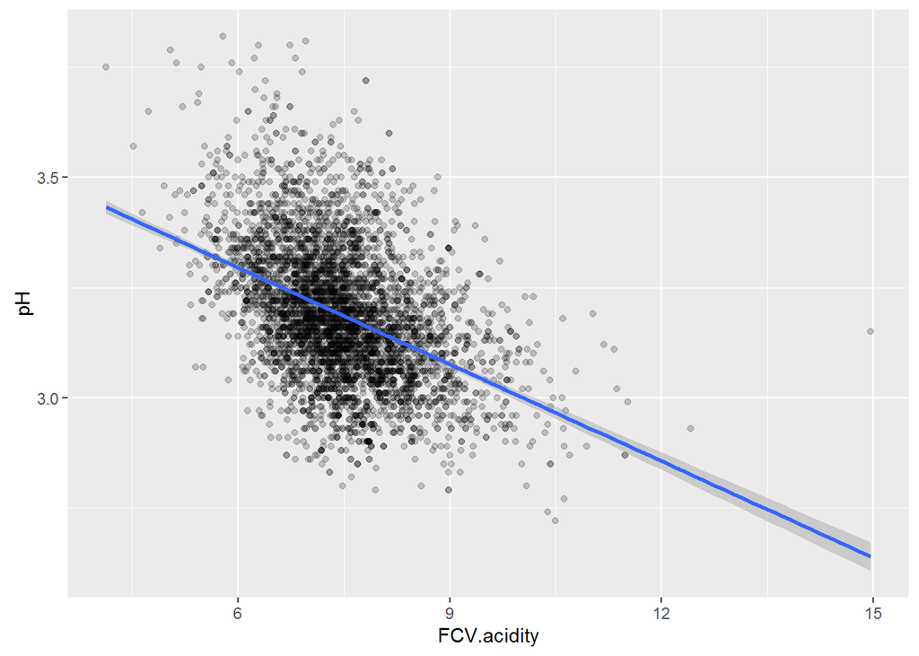

```
##
##  Pearson's product-moment correlation
##
## data:  wine$FCV.acidity and wine$pH
## t = -33.388, df = 4896, p-value < 2.2e-16
## alternative hypothesis: true correlation is not equal to 0
## 95 percent confidence interval:
##  -0.4531918 -0.4075605
## sample estimates:
##        cor
## -0.4306513
```

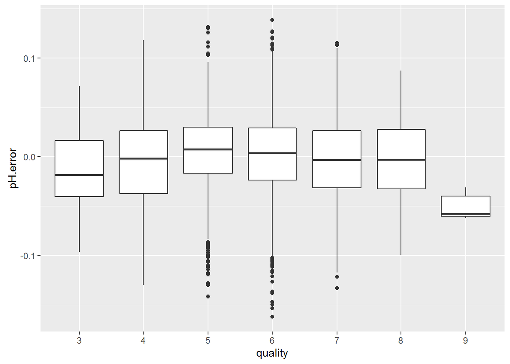

The median error % for most quality ratings floats around 0. It is quite interesting that many wines with rating of 3 have a large negative error. Based on this we can conclude that FCV acidity is a worse predictor for pH for many wines rated as ‘bad’. This means that there are other components that affect the pH.

As previously mentioned, I assumed that free & total sulfur are dependent. I made a plot in order to prove or reject this thesis.

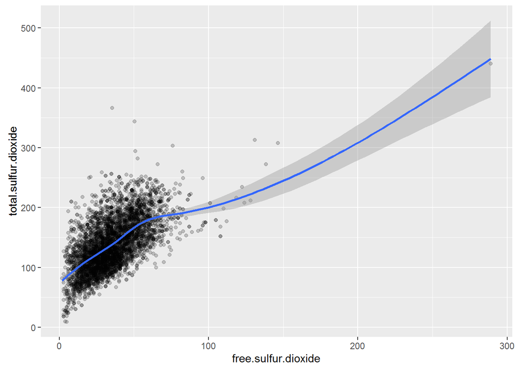

```
##
##  Pearson's product-moment correlation
##
## data:  wine$free.sulfur.dioxide and wine$total.sulfur.dioxide
## t = 54.645, df = 4896, p-value < 2.2e-16
## alternative hypothesis: true correlation is not equal to 0
## 95 percent confidence interval:
##  0.5977994 0.6326026
## sample estimates:
##      cor
## 0.615501
```

The strong relationship between those two variables is obvious. Aside from the FCV acidity, this seems to be the other very strong relationship in the data. In addition the clear floor on the above graph, indicates that the free sulfur is a subset of the total sulfur.

## Multivariate plots and analysis

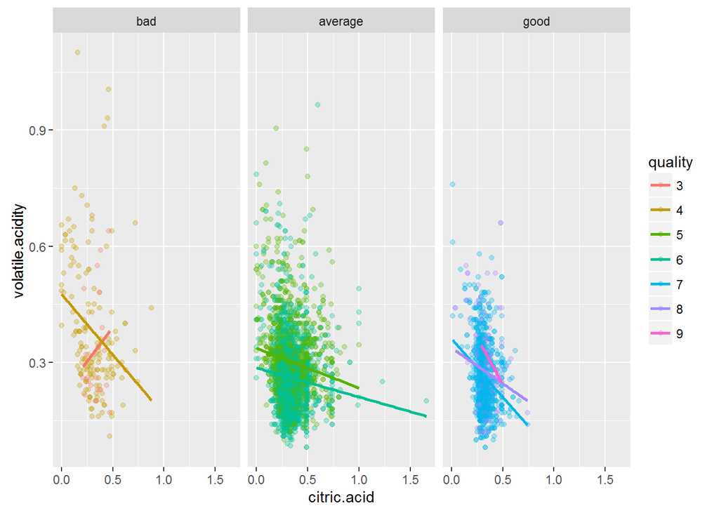

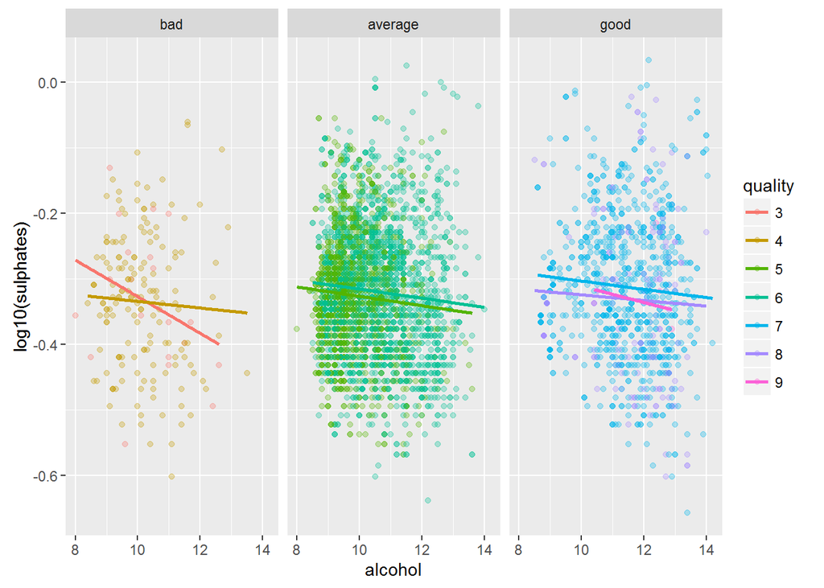

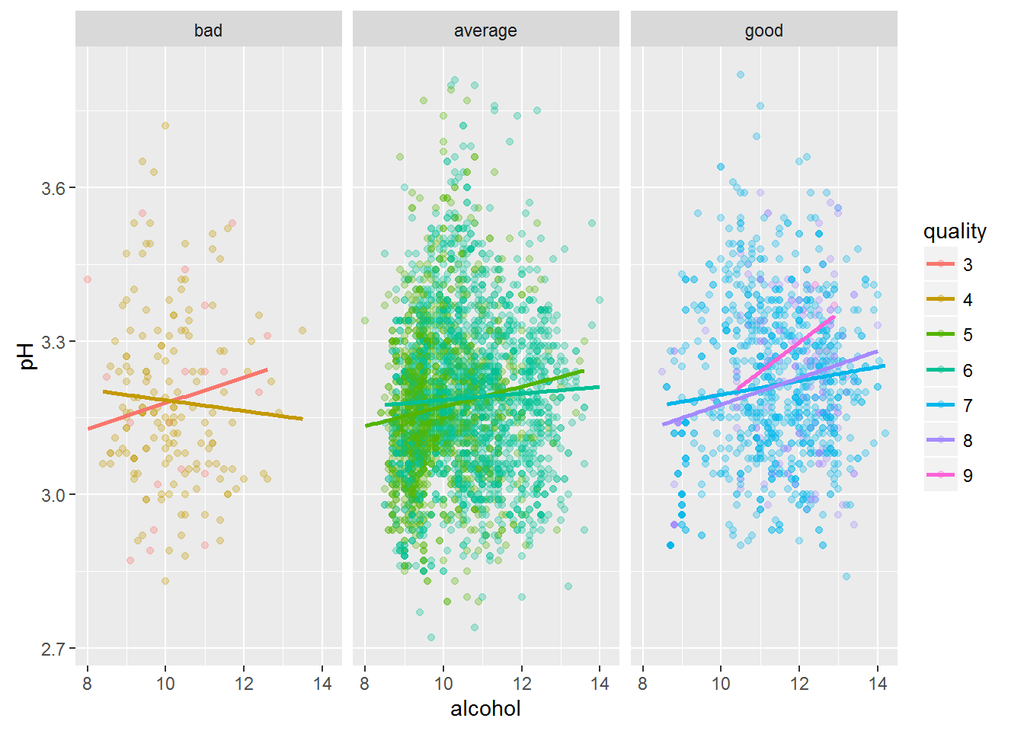

# Final Plots and Summary

## Plot 1: Effect of acids on wine quality

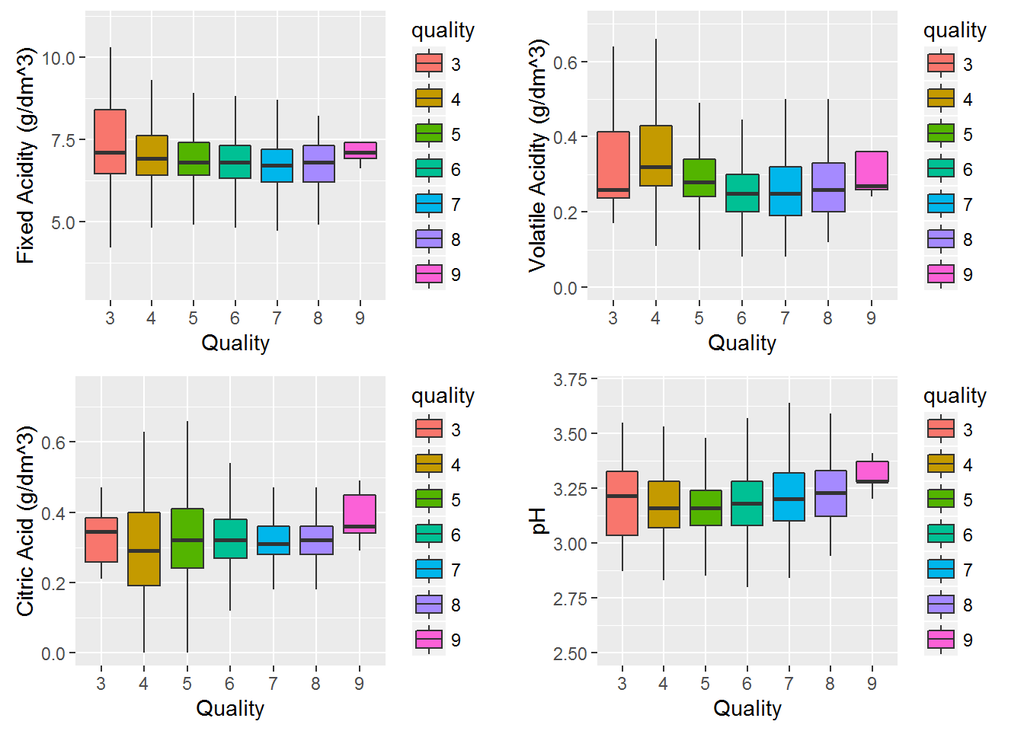

```
##    Fixed Acidity Volatile Acidity   Citric Acidity               pH
##     -0.113662831     -0.194722969     -0.009209091      0.099427246
```

## Plot 2: Effect of Alcohol on wine quality

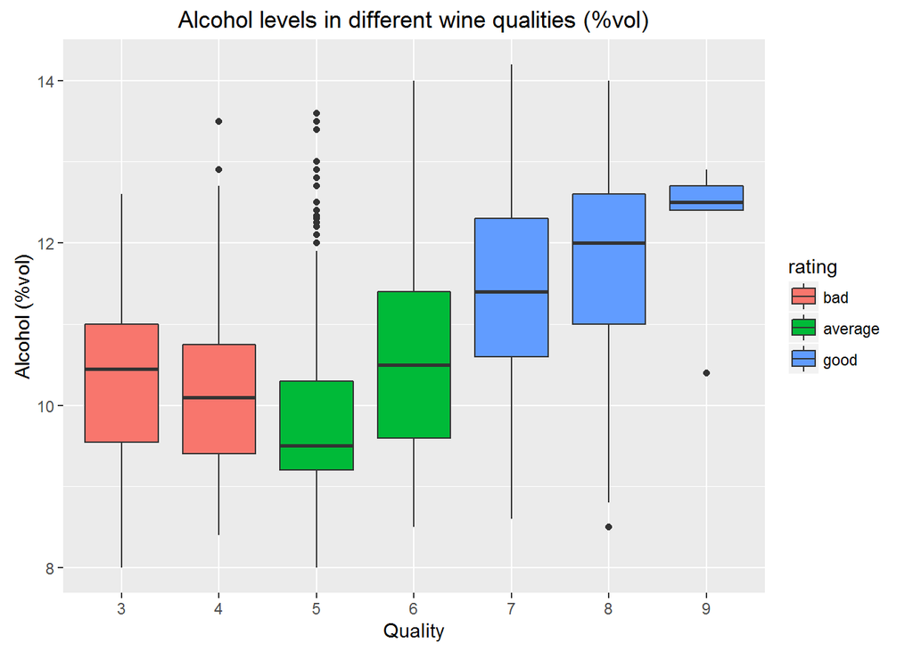

This boxplot illustrates the effect of alcohol content on wine quality. In general higher alcohol content correlates positively with wine quality. But we need to keep in mind that the intervals & outliers point to the fact that alcohol alone is not a reason for a higher quality. The above conclusion is also supported by the correlation analysis. As displayed by the below analysis, the dependence between the Alcohol & Quality is quite strong and positive. In other words it can be presumed that when the alcohol content increases the quality rating will also increase.

```
## Alcohol vs Quality
##          0.4355747
```

## Plot 3: What makes wines good, average or bad?

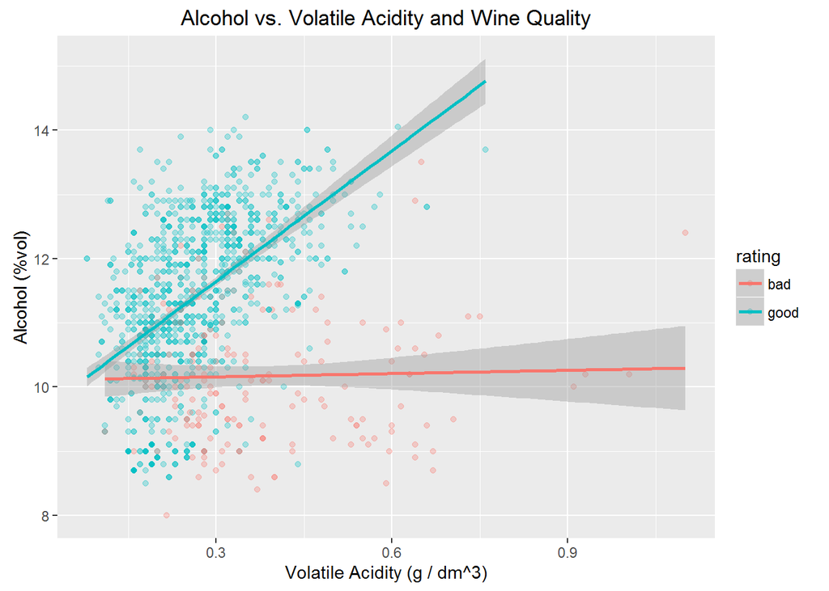

# Reflection

At the beginning of the analysis I have never imagined that acids(especially volatile) will turn to be such an important factor for quality. Alcohol content was expected to be a main contributor to quality.

However, wine quality is ultimately a subjective measure, scored by wine experts. Keeping this in mind, the correlations for these variables are within reasonable bounds. The visuals can adequately illustrate the factors that make good wines ‘good’ and bad wines ‘bad’. Further study with inferential statistics could be done to quantitatively confirm the observations.

As my chemistry knowledge is quite bad I struggled the most with understanding & explaining the data in context. For me the success is that I was able to grasp the background on the study. In other words I was able to understand what is pH for example, I was able to relate acids with something more familiar like quality or rating. The biggest success for me is to understand what is the difference between acids & sulphates and how they relate to something basic like quality rating.

# References

- http://waterhouse.ucdavis.edu/whats-in-wine
- http://www.sofastatistics.com/wiki/doku.php?id=help:pearsonsr
- http://www.r-bloggers.com/wanted-a-perfect-scatterplot-with-marginals/
- http://www.r-bloggers.com/principal-components-regression-in-r-part-2/